**Contenido**

1. Solla - Colombia
2. Problema
3. Introducción
4. Objetivos
5. Metodología
6. Resultados
7. Conclusiones

**Solla - Colombia**

[figure not shown]

**Problema: implicaciones**

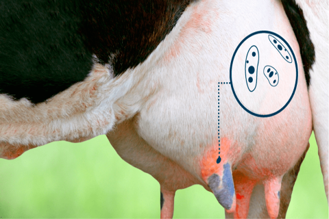

- Incremento de costos en sistemas de producción
- Disminución en desempeño reproductivo
- Disminución en desempeño productivo
- Pérdida de calidad composicional de la leche
- Riesgos para la salud humana

**Problema: detección en campo**

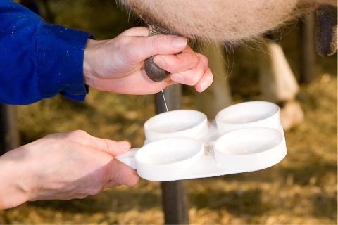

- Mastitis clínica y subclínica
- Diagnóstico en campo: California Mastitis Test (C.M.T.)
- Recuento de células somáticas (RCS)
- Incremento de RCS:
- Golpes
- Malas condiciones sanitarias
- Estrés calórico
- Altas precipitaciones

**Problema: CMT en campo**

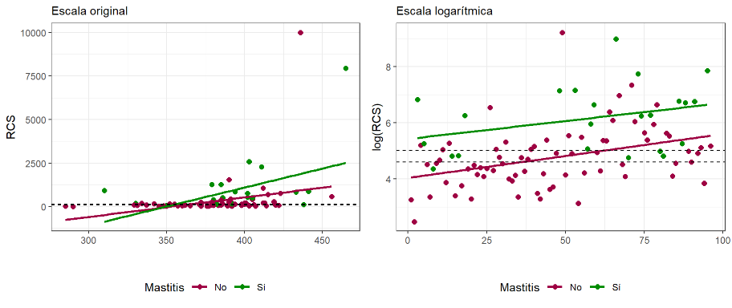

**Introducción**

- Desarrollos previos al año 2000
- [1980 - The diagnostic value of measuring the electric conductivity of milk.](https://europepmc.org/abstract/med/6775407)
- [1982 - Relationship Between Lactation Measures of Somatic Cell Concentration and Milk Yield.](https://www.sciencedirect.com/science/article/pii/S0022030282822078)
- 1992 - Electrical conductivity of Milk: Measurement, Modifiers and Meta Analysis of Mastitis Detection Performance.
- [1998 - Evaluation of a hand-held electrical conductivity meter for detection of subclinical mastitis in cattle.](https://europepmc.org/abstract/med/9736381)
- Desarrollos posteriores al año 2000
- [2010 - Detection of mastitis and its stage of progression by automatic milking systems using artificial neural networks](https://www.researchgate.net/publication/40766390_Detection_of_mastitis_and_its_stage_of_progression_by_automatic_milking_systems_using_artificial_neural_networks)
- [2013 - Application of the Support Vector Machine to Predict Subclinical Mastitis in Dairy Cattle.](https://www.ncbi.nlm.nih.gov/pmc/articles/PMC3886278/)
- 2016 - Bayesian integration of sensor information and a multivariate dynamic linear model for prediction of dairy cow mastitis.
- [2018 - Integration of machine learning and meta-analysis identifies the transcriptomic bio-signature of mastitis disease in cattle](https://journals.plos.org/plosone/article?id=10.1371/journal.pone.0191227)

**Objetivos**

[figure not shown]

- **General:** evaluar el desempeño predictivo de modelos de aprendizaje automático para detección de mastitis subclínica en vacas lecheras de Colombia.
- **Específicos:**
- Determinar variables que sirvan como biomarcadores de la patología.
- Probar algoritmos que permitan generar entendimiento (derivaciones biológicas) acerca de la enfermedad con base en datos de campo.
- Mostrar a R como una herramienta potente para diagnóstico temprano de patologías de interés zootécnico.

**Metodología**

**Metodología**

- **Modelos de Machine Learning (no supervisado):**
- Análisis de Componentes Principales
- Pruebas de normalidad (*Shapiro Wilk*)
- Correlaciones no paramétricas de *Spearman*
- **Modelos de Machine Learning (supervisado):**
- **Modelos de clasificación:**
- KNN (k-nearest neighbors)
- Árboles de decisión
- Análisis Discriminante Lineal (LDA)
- Análisis Discriminante Cuadrático (QDA)
- Naive Bayes
- Random Forest
- Métodos de Boosting
- Support Vector Machine (SVM)
- Regresión Logística

**Metodología**

[figure not shown]

- **caret**
- createDataPartition()
- trainControl(): method = "repeatedcv"
- resamples()
- train(): metric = "Accuracy"
- **FactoMineR**
- PCA()
- **corrplot**
- **plotly**

**Resultados**

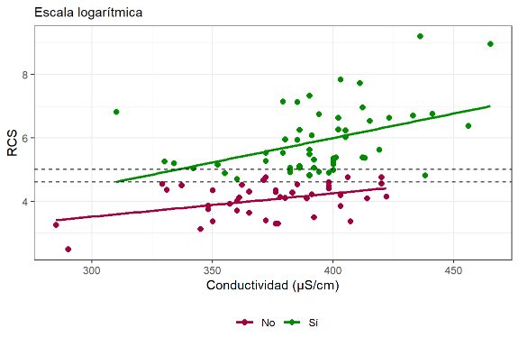

**Resultados (Normalidad)**

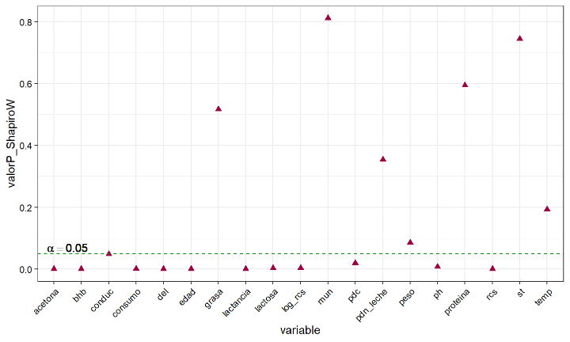

**Resultados (Correlaciones)**

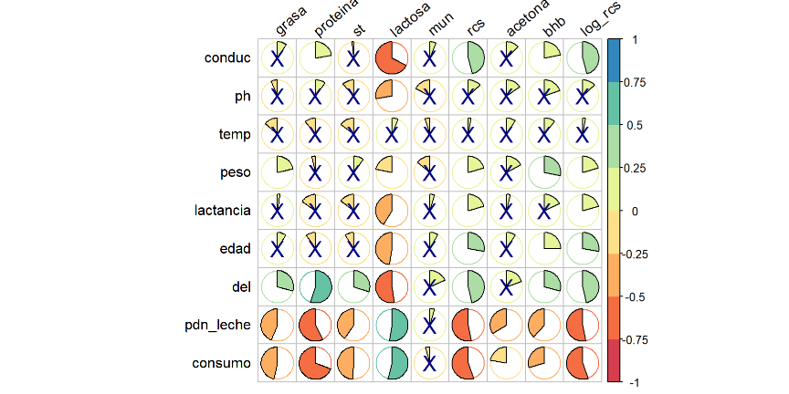

**Resultados (ACP)**

[figure not shown]

**Resultados - Importancia de variables**

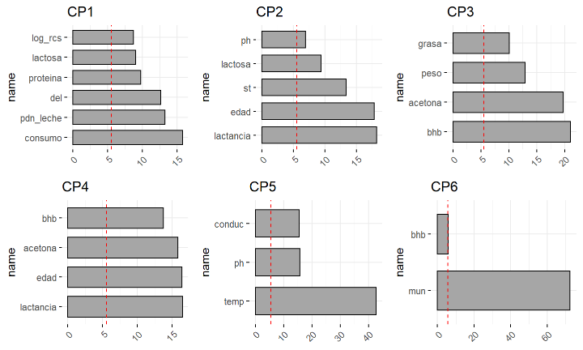

**Resultados (Selección de predictores)**

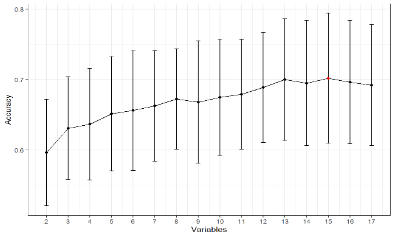

**Resultados (Accuracy Training)**

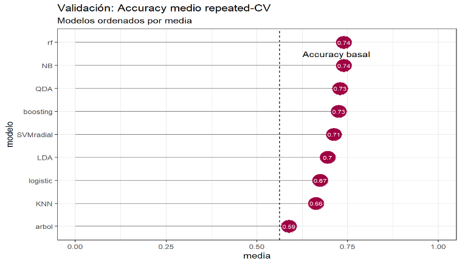

**Resultados (Variabilidad en predicciones)**

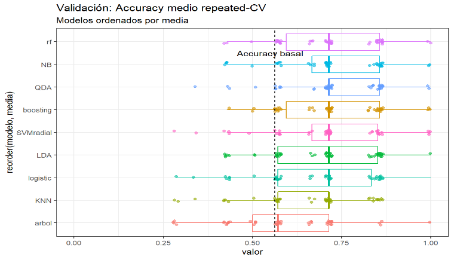

**Resultados (Accuracy Train y Test)**

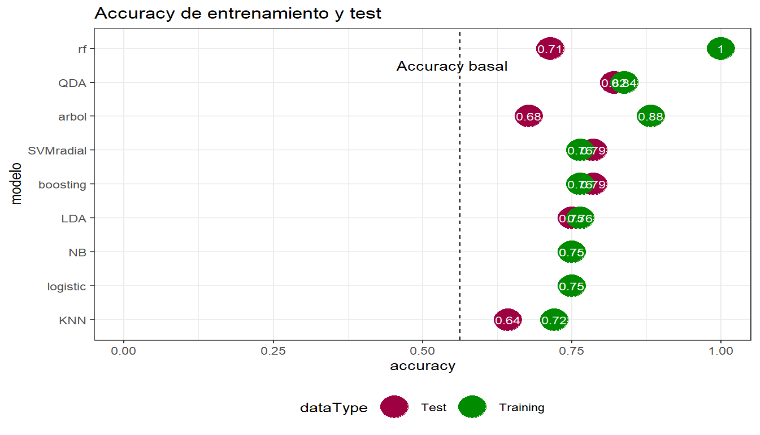

**Resultados (Accuracy en Test)**

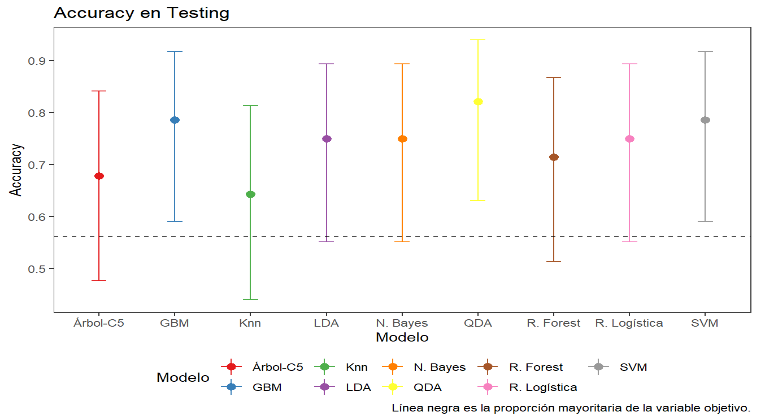

**Resultados (Desempeño de modelos)**

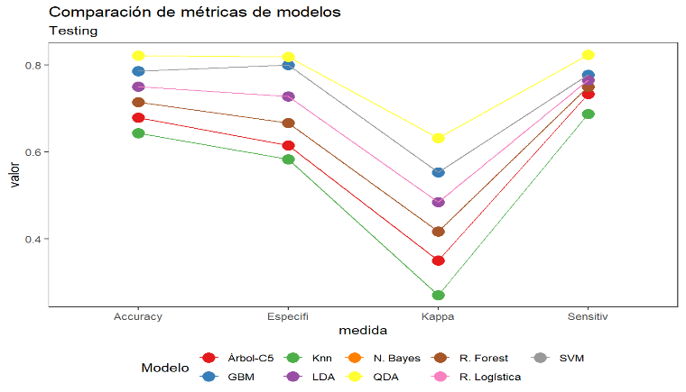

**Conclusiones**

- La conductividad eléctrica se constituye como una variable de alta influencia en la capacidad de discriminar de manera adecuada vacas enfermas y sanas, dada su alta correlación con el RCS.
- En general, los algoritmos de *Machine Learning* presentaron desempeños óptimos para clasificación de patologías de interés zootécnico.
- Las variables consideradas para entrenar los modelos, pueden ser vistas como biomarcadores potenciales para detectar mastitis subclínica a nivel de campo.
- R demuestra ser una herramienta tecnológica de gran valor para el sector agrario.

[figure not shown]